# R Markdown Exercises

Dustin Pluta

February 20, 2017

# Exercises

**Edit this R Markdown document to include your solutions. Experiment with formatting and the many available options.**

### Iris Data

1. Use `ggplot` to display the scatterplot the `iris` data with $x$-axis `Petal.Length` and $y$-axis `Petal.Width`. Color the points according to the species.

*Solution*

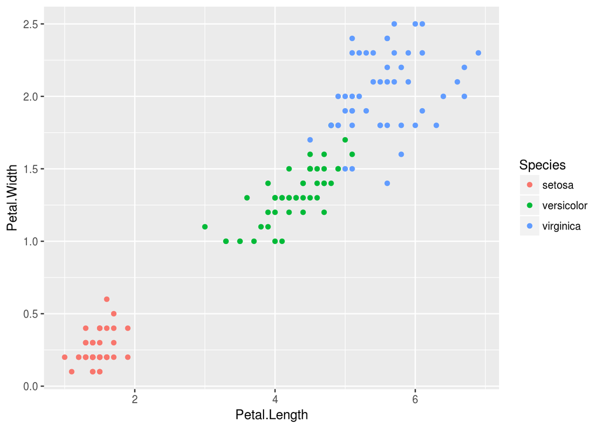

```r
library(ggplot2)
ggplot(iris, aes(Petal.Length, Petal.Width, color = Species)) + geom_point()
```

- Add a horizontal rule between this problem and the previous problem using “***" on its own line, with newlines above and below.
- Add a link to the iris data set on the UCI Machine learning repository and a brief description of the data.

**[Iris Data on the UCI ML Repo](https://archive.ics.uci.edu/ml/datasets/Iris)**

3. Use `dplyr` to select the petal length and petal width of only the Virginica species, and output this data as a table.

### IMDB Data

4. Read in the IMDB Data and print the column names.

`imdb <- read.csv("~/Data/movie_metadata.csv")`

```r
imdb <- read.csv("Data/movie_metadata.csv")
colnames(imdb)
```

```
##  [1] "color"                     "director_name"
##  [3] "num_critic_for_reviews"    "duration"
##  [5] "director_facebook_likes"   "actor_3_facebook_likes"
##  [7] "actor_2_name"              "actor_1_facebook_likes"
##  [9] "gross"                     "genres"
## [11] "actor_1_name"              "movie_title"
## [13] "num_voted_users"           "cast_total_facebook_likes"
## [15] "actor_3_name"              "facenumber_in_poster"
## [17] "plot_keywords"             "movie_imdb_link"
## [19] "num_user_for_reviews"      "language"
## [21] "country"                   "content_rating"
## [23] "budget"                    "title_year"
## [25] "actor_2_facebook_likes"    "imdb_score"
## [27] "aspect_ratio"              "movie_facebook_likes"
```

- Use `dplyr` to create a new data frame called `imdb_selected` with just movie score and $\log_{10}($budget).
- Create a scatterplot of this data using `ggplot`

[figure not shown]

```r
library(ggplot2)
ggplot(data=imdb, aes(x=log10(budget), y=imdb_score)) +
geom_point(aes(colour=gross), alpha=0.5) +
geom_smooth() +
scale_color_continuous(name='Box office gross', breaks = c(2e+8, 4e+8, 6e+8),
labels = c('2 million', '4 million', '6 million'),
low = 'blue', high = 'red') +
annotate('point', x=8.3, y=8.3, colour='red', size=4) +
annotate('text', x=8.3, y=8.6, label='Toy Story 3', fontface='italic', size=6, angle=30) +
theme_bw() +
labs(title='IMDB Movies') +
theme(plot.title=element_text(size=rel(2), colour='blue')) +
theme(legend.position=c(0.9, 0.2))
```

```r
library(dplyr)
avg_budgets <- filter(imdb, actor_1_name %in% c('Nicolas Cage', 'Bruce Willis')) %>%
  select(c(budget, actor_1_name)) %>%
  group_by(actor_1_name) %>%
  summarize(mean(budget))
knitr::kable(avg_budgets)
```

| actor_1_name | mean(budget) |
| --- | --- |
| Bruce Willis | 56066667 |
| Nicolas Cage | 51752121 |